# Logistic classification

Let’s see what happens when I try a ROC curve for a simple logistic prediction. How trashy does it look?

```r
library(gdata)
library(nnet)
load('~/data/baseline_prediction/combined_descriptives_12172018.RData.gz')
clin = read.csv('~/data/baseline_prediction/long_clin_11302018.csv')
df = merge(clin, data, by='MRN')
idx = df$diag_group != 'new_onset'
idx2 = !is.na(df$inatt_vol_lh) | !is.na(df$inatt_AD_clu1) | !is.na(df$inatt_melodic_DMN)
imaging = df[idx & idx2,]
imaging[imaging$OLS_inatt_slope <= -.33, 'OLS_inatt_categ'] = 'marked'
imaging[imaging$OLS_inatt_slope > -.33 & imaging$OLS_inatt_slope <= 0, 'OLS_inatt_categ'] = 'mild'
imaging[imaging$OLS_inatt_slope > 0, 'OLS_inatt_categ'] = 'deter'
imaging[imaging$DX == 'NV', 'OLS_inatt_categ'] = 'NV'
imaging$OLS_inatt_categ = as.factor(imaging$OLS_inatt_categ)
imaging$OLS_inatt_categ = relevel(imaging$OLS_inatt_categ, ref='NV')
imaging$OLS_HI_categ = NULL
imaging[imaging$OLS_HI_slope <= -.5, 'OLS_HI_categ'] = 'marked'
imaging[imaging$OLS_HI_slope > -.5 & imaging$OLS_HI_slope <= 0, 'OLS_HI_categ'] = 'mild'
imaging[imaging$OLS_HI_slope > 0, 'OLS_HI_categ'] = 'deter'
imaging[imaging$DX == 'NV', 'OLS_HI_categ'] = 'NV'
imaging$OLS_HI_categ = as.factor(imaging$OLS_HI_categ)
imaging$OLS_HI_categ = relevel(imaging$OLS_HI_categ, ref='NV')
load('~/data/baseline_prediction/combined_descriptives_12172018.RData.gz')
clin = read.csv('~/data/baseline_prediction/long_clin_11302018.csv')
df = merge(clin, data, by='MRN')
idx = df$diag_group != 'new_onset'
struct = df[!is.na(df$HI_vol_rh) & idx,]
load('~/data/baseline_prediction/struct_volume_11142018_260timeDiff12mo.RData.gz')
struct = merge(struct, data, by='MRN') # put mask ids in combined dataset
mprage = read.xls('~/data/baseline_prediction/long_scans_08072018.xlsx',
                  sheet='mprage')
struct = merge(struct, mprage, by.x='mask.id', by.y='Mask.ID...Scan') # get demographics
qc = read.csv('/Volumes/Shaw/MasterQC/master_qc_20190110.csv')
struct = merge(struct, qc, by.x='mask.id', by.y='Mask.ID') # get QC scores
df = merge(struct, imaging, by='MRN')
dim(df)
```

```
[1]  241 5242
```

So, the idea now is to regress out some of the garbage to see what happens:

```r
library(MASS)
library(nlme)
fm = as.formula('inatt_vol_lh.x ~ Sex...Subjects + int_avg_freesurfer5.3 + age_at_scan + I(age_at_scan^2) + ext_avg_freesurfer5.3 + int_avg_freesurfer5.3 + mprage_QC')
res.lme = lme(fm, random=~1|nuclearFamID.x, data=df, na.action=na.omit, method='ML')
step <- stepAIC(res.lme, direction = "both", trace = F)
print(summary(step))
```

```
Linear mixed-effects model fit by maximum likelihood
 Data: df
       AIC      BIC    logLik
  2087.075 2111.469 -1036.538

Random effects:
 Formula: ~1 | nuclearFamID.x
        (Intercept) Residual
StdDev:    9.179982  15.4721

Fixed effects: inatt_vol_lh.x ~ Sex...Subjects + int_avg_freesurfer5.3 + age_at_scan +      I(age_at_scan^2)
                         Value Std.Error  DF   t-value p-value
(Intercept)           40.51186 18.024834 190  2.247558  0.0258
Sex...SubjectsMale     8.49817  2.451877  46  3.465986  0.0012
int_avg_freesurfer5.3 -6.40137  3.270641  46 -1.957223  0.0564
age_at_scan           11.45024  3.501252  46  3.270326  0.0020
I(age_at_scan^2)      -0.57113  0.177151  46 -3.223990  0.0023
 Correlation:
                      (Intr) S...SM i__5.3 ag_t_s
Sex...SubjectsMale    -0.082
int_avg_freesurfer5.3 -0.383  0.036
age_at_scan           -0.918 -0.030  0.028
I(age_at_scan^2)       0.884  0.036 -0.013 -0.989

Standardized Within-Group Residuals:
        Min          Q1         Med          Q3         Max
-2.16756082 -0.59890144 -0.08626203  0.45070491  2.92646863

Number of Observations: 241
Number of Groups: 191
```

```r
mycluster = residuals(step)
summary(aov(lm(mycluster ~ df$OLS_inatt_categ)))
```

```
                    Df Sum Sq Mean Sq F value Pr(>F)
df$OLS_inatt_categ   3   2847   948.9   5.461 0.0012 **
Residuals          237  41181   173.8
---
Signif. codes:  0 ‘***’ 0.001 ‘**’ 0.01 ‘*’ 0.05 ‘.’ 0.1 ‘ ’ 1
```

```r
pairwise.t.test(mycluster, df$OLS_inatt_categ, p.adjust.method='none')
```

```
    Pairwise comparisons using t tests with pooled SD

data:  mycluster and df$OLS_inatt_categ

       NV     deter   marked
deter  0.0552 -       -
marked 0.0098 9.2e-05 -
mild   0.5574 0.3393  0.0100

P value adjustment method: none
```

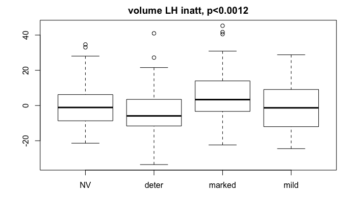

```r
fm = as.formula(mycluster ~ df$OLS_inatt_categ)
fit = aov(lm(fm))
boxplot(fm)
title(sprintf('volume LH inatt, p<%.4f', summary(fit)[[1]][1, 'Pr(>F)']))
```

So, the marked improvement group is significantly better (nominally) than all other groups. If we were to make a ROC plot one vs everything for all groups, would the curve for marked be somewhat decent? I’m not sure how to do that in R… so, let’s save all variables into a CSV and do it in Python!

```r
out_df = data.frame(MRN=df$MRN, inatt_struct=mycluster, OLS_inatt_categ=df$OLS_inatt_categ,
                    OLS_HI_categ=df$OLS_HI_categ)
head(out_df)
```

```
      MRN inatt_struct OLS_inatt_categ OLS_HI_categ
1 4150739    22.123579              NV           NV
2 4380770    -8.543250           deter         mild
3 4387685   -33.536726           deter         mild
4 4401645   -13.226522          marked       marked
5 4423501    -5.607589           deter         mild
6 4432605    -1.184798            mild       marked
```

And do the same thing for other clusters:

```r
fm = as.formula('HI_vol_rh.x ~ Sex...Subjects + int_avg_freesurfer5.3 + age_at_scan + I(age_at_scan^2) + ext_avg_freesurfer5.3 + int_avg_freesurfer5.3 + mprage_QC')
res.lme = lme(fm, random=~1|nuclearFamID.x, data=df, na.action=na.omit, method='ML')
step <- stepAIC(res.lme, direction = "both", trace = F)
print(summary(step))
```

```
Linear mixed-effects model fit by maximum likelihood
 Data: df
       AIC      BIC    logLik
  2054.733 2075.642 -1021.367

Random effects:
 Formula: ~1 | nuclearFamID.x
        (Intercept) Residual
StdDev:    5.064072 15.99513

Fixed effects: HI_vol_rh.x ~ Sex...Subjects + I(age_at_scan^2) + mprage_QC
                      Value Std.Error  DF   t-value p-value
(Intercept)        86.97019  4.899367 190 17.751312  0.0000
Sex...SubjectsMale  6.26647  2.319393  47  2.701770  0.0096
I(age_at_scan^2)    0.03674  0.024870  47  1.477159  0.1463
mprage_QC          -6.25577  2.452158  47 -2.551130  0.0141
 Correlation:
                   (Intr) S...SM I(__^2
Sex...SubjectsMale -0.377
I(age_at_scan^2)   -0.591  0.040
mprage_QC          -0.809  0.059  0.199

Standardized Within-Group Residuals:
        Min          Q1         Med          Q3         Max
-2.07898963 -0.70755934 -0.09903456  0.45632171  5.23611787

Number of Observations: 241
Number of Groups: 191
```

```r
mycluster = residuals(step)
summary(aov(lm(mycluster ~ df$OLS_HI_categ)))
```

```
                 Df Sum Sq Mean Sq F value   Pr(>F)
df$OLS_HI_categ   3   3840  1279.9   5.787 0.000781 ***
Residuals       237  52413   221.2
---
Signif. codes:  0 ‘***’ 0.001 ‘**’ 0.01 ‘*’ 0.05 ‘.’ 0.1 ‘ ’ 1
```

```r
pairwise.t.test(mycluster, df$OLS_HI_categ, p.adjust.method='none')
```

```
    Pairwise comparisons using t tests with pooled SD

data:  mycluster and df$OLS_HI_categ

       NV     deter   marked
deter  0.0041 -       -
marked 0.0522 4.7e-05 -
mild   0.9272 0.0145  0.1046

P value adjustment method: none
```

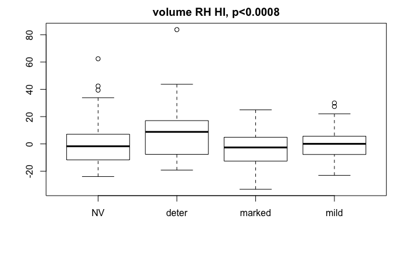

```r
fm = as.formula(mycluster ~ df$OLS_HI_categ)
fit = aov(lm(fm))
boxplot(fm)
title(sprintf('volume RH HI, p<%.4f', summary(fit)[[1]][1, 'Pr(>F)']))
```

```r
out_df$HI_struct = mycluster
```

## DTI

Let’s move on to the DTI clusters:

```r
load('~/data/baseline_prediction/combined_descriptives_12172018.RData.gz')
clin = read.csv('~/data/baseline_prediction/long_clin_11302018.csv')
df = merge(clin, data, by='MRN')
idx = df$diag_group != 'new_onset'
dti = df[!is.na(df$inatt_AD_clu1) & idx,]
load('~/data/baseline_prediction/dti_rd_voxelwise_n272_09212018.RData.gz')
dti = merge(dti, data, by='MRN') # put mask ids in combined dataset
mprage = read.xls('~/data/baseline_prediction/long_scans_08072018.xlsx',
                  sheet='dti')
dti = merge(dti, mprage, by.x='mask.id', by.y='Mask.ID') # get demographics
qc = read.csv('/Volumes/Shaw/MasterQC/master_qc_20190110.csv')
dti = merge(dti, qc, by.x='mask.id', by.y='Mask.ID') # get QC scores
df = merge(dti, imaging, by='MRN')
```

And like before we residualize the cluster prior to looking for differences:

```r
fm = as.formula('inatt_AD_clu1.x ~ Sex + norm.rot + I(norm.rot^2) + norm.trans + I(norm.trans^2) + age_at_scan + I(age_at_scan^2)')
res.lme = lme(fm, random=~1|nuclearFamID.x, data=df, na.action=na.omit, method='ML')
step <- stepAIC(res.lme, direction = "both", trace = F)
print(summary(step))
```

```
Linear mixed-effects model fit by maximum likelihood
 Data: df
        AIC       BIC   logLik
  -782.2527 -753.9856 399.1264

Random effects:
 Formula: ~1 | nuclearFamID.x
        (Intercept)   Residual
StdDev:  0.02728403 0.04252661

Fixed effects: inatt_AD_clu1.x ~ Sex + norm.rot + norm.trans + I(norm.trans^2) +      I(age_at_scan^2)
                      Value  Std.Error  DF   t-value p-value
(Intercept)       1.4072914 0.01332348 193 105.62491  0.0000
SexMale           0.0165391 0.00678675  54   2.43697  0.0181
norm.rot          0.3817851 0.24013663  54   1.58987  0.1177
norm.trans       -0.0560023 0.01592645  54  -3.51631  0.0009
I(norm.trans^2)   0.0126256 0.00401965  54   3.14098  0.0027
I(age_at_scan^2) -0.0002946 0.00007075  54  -4.16360  0.0001
 Correlation:
                 (Intr) SexMal nrm.rt nrm.tr I(.^2)
SexMale          -0.320
norm.rot         -0.056  0.069
norm.trans       -0.704 -0.035 -0.324
I(norm.trans^2)   0.676 -0.006  0.167 -0.958
I(age_at_scan^2) -0.530  0.010  0.067  0.056 -0.035

Standardized Within-Group Residuals:
        Min          Q1         Med          Q3         Max
-3.43740306 -0.58399358  0.06027744  0.66019898  2.40385384

Number of Observations: 253
Number of Groups: 194
```

```r
mycluster = residuals(step)
summary(aov(lm(mycluster ~ df$OLS_inatt_categ)))
```

```
                    Df Sum Sq  Mean Sq F value  Pr(>F)
df$OLS_inatt_categ   3 0.0173 0.005772   4.466 0.00447 **
Residuals          249 0.3218 0.001292
---
Signif. codes:  0 ‘***’ 0.001 ‘**’ 0.01 ‘*’ 0.05 ‘.’ 0.1 ‘ ’ 1
```

```r
pairwise.t.test(mycluster, df$OLS_inatt_categ, p.adjust.method='none')
```

```
    Pairwise comparisons using t tests with pooled SD

data:  mycluster and df$OLS_inatt_categ

       NV     deter  marked
deter  0.0025 -      -
marked 0.4361 0.0009 -
mild   0.5113 0.0811 0.2300

P value adjustment method: none
```

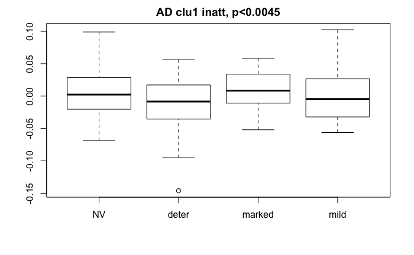

```r
fm = as.formula(mycluster ~ df$OLS_inatt_categ)
fit = aov(lm(fm))
boxplot(fm)
title(sprintf('AD clu1 inatt, p<%.4f', summary(fit)[[1]][1, 'Pr(>F)']))
```

Now the deteriorating group is worse than most of the other groups. Let’s include it in our output:

```r
tmp_df = data.frame(MRN=df$MRN, inatt_AD=mycluster)
out_df = merge(out_df, tmp_df, all.x=T, all.y=T)
dim(out_df)
```

```
[1] 272   6
```

How about the other AD cluster? Apparently I didn’t even plot the second AD inatt cluster in adhd_NOS_descriptives.md. So, let’s switch right to the RD HI cluster:

```r
fm = as.formula('HI_RD_clu1.x ~ Sex + norm.rot + I(norm.rot^2) + norm.trans + I(norm.trans^2) + age_at_scan + I(age_at_scan^2)')
res.lme = lme(fm, random=~1|nuclearFamID.x, data=df, na.action=na.omit, method='ML')
step <- stepAIC(res.lme, direction = "both", trace = F)
print(summary(step))
```

```
Linear mixed-effects model fit by maximum likelihood
 Data: df
       AIC       BIC   logLik
  -1067.33 -1046.129 539.6649

Random effects:
 Formula: ~1 | nuclearFamID.x
        (Intercept)   Residual
StdDev:  0.01347143 0.02550795

Fixed effects: HI_RD_clu1.x ~ Sex + age_at_scan + I(age_at_scan^2)
                      Value   Std.Error  DF   t-value p-value
(Intercept)       0.6748072 0.022416098 193 30.103688  0.0000
SexMale           0.0061215 0.003860110  56  1.585836  0.1184
age_at_scan      -0.0210890 0.004742445  56 -4.446860  0.0000
I(age_at_scan^2)  0.0008384 0.000241687  56  3.468834  0.0010
 Correlation:
                 (Intr) SexMal ag_t_s
SexMale          -0.090
age_at_scan      -0.978 -0.031
I(age_at_scan^2)  0.939  0.034 -0.986

Standardized Within-Group Residuals:
        Min          Q1         Med          Q3         Max
-3.56904218 -0.59958959  0.01443782  0.63860391  2.84694442

Number of Observations: 253
Number of Groups: 194
```

```r
mycluster = residuals(step)
summary(aov(lm(mycluster ~ df$OLS_HI_categ)))
```

```
                 Df  Sum Sq   Mean Sq F value Pr(>F)
df$OLS_HI_categ   3 0.00364 0.0012132   2.354 0.0726 .
Residuals       249 0.12831 0.0005153
---
Signif. codes:  0 ‘***’ 0.001 ‘**’ 0.01 ‘*’ 0.05 ‘.’ 0.1 ‘ ’ 1
```

```r
pairwise.t.test(mycluster, df$OLS_HI_categ, p.adjust.method='none')
```

```
    Pairwise comparisons using t tests with pooled SD

data:  mycluster and df$OLS_HI_categ

       NV    deter marked
deter  0.311 -     -
marked 0.368 0.105 -
mild   0.070 0.586 0.015

P value adjustment method: none
```

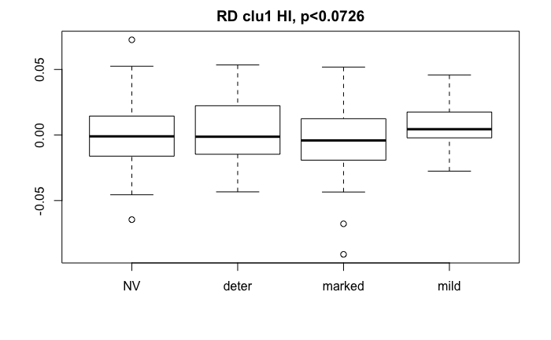

```r
fm = as.formula(mycluster ~ df$OLS_HI_categ)
fit = aov(lm(fm))
boxplot(fm)
title(sprintf('RD clu1 HI, p<%.4f', summary(fit)[[1]][1, 'Pr(>F)']))
```

This one looks a bit funky. The only significant difference is between marked and mild??? The ANOVA is not really signifcant either, so I won’t include it in the output.

## rsFMRI

```r
load('~/data/baseline_prediction/combined_descriptives_12172018.RData.gz')
clin = read.csv('~/data/baseline_prediction/long_clin_11302018.csv')
df = merge(clin, data, by='MRN')
idx = df$diag_group != 'new_onset'
fmri = df[!is.na(df$inatt_melodic_limbic) & idx,]
load('~/data/baseline_prediction/melodic_inter_IC11_12142018.RData.gz')
fmri = merge(fmri, data, by='MRN') # put mask ids in combined dataset
mprage = read.xls('~/data/baseline_prediction/long_scans_08072018.xlsx',
                  sheet='mprage')
fmri = merge(fmri, mprage, by.x='mask.id', by.y='Mask.ID...Scan') # get demographics
qc = read.csv('/Volumes/Shaw/MasterQC/master_qc_20190110.csv')
fmri = merge(fmri, qc, by.x='mask.id', by.y='Mask.ID') # get QC scores
df = merge(fmri, imaging, by='MRN')
dim(df)
```

```
[1]   196 44329
```

Like before, we residualize the cluster before evaluating it:

```r
fm = as.formula('inatt_melodic_limbic.x ~ age_at_scan + I(age_at_scan^2) + enormGoodTRs_fmri01 + I(enormGoodTRs_fmri01^2) + Sex...Subjects')
res.lme = lme(fm, random=~1|nuclearFamID.x, data=df, na.action=na.omit, method='ML')
step <- stepAIC(res.lme, direction = "both", trace = F)
print(summary(step))
```

```
Linear mixed-effects model fit by maximum likelihood
 Data: df
       AIC      BIC   logLik
  660.3079 673.4204 -326.154

Random effects:
 Formula: ~1 | nuclearFamID.x
         (Intercept) Residual
StdDev: 9.200126e-05 1.277765

Fixed effects: inatt_melodic_limbic.x ~ I(enormGoodTRs_fmri01^2)
                            Value Std.Error  DF   t-value p-value
(Intercept)                1.9203   0.18844 153 10.190652   0e+00
I(enormGoodTRs_fmri01^2) 144.5737  34.90160  41  4.142323   2e-04
 Correlation:
                         (Intr)
I(enormGoodTRs_fmri01^2) -0.873

Standardized Within-Group Residuals:
        Min          Q1         Med          Q3         Max
-2.82400951 -0.60966976 -0.08677895  0.60332032  3.15034883

Number of Observations: 196
Number of Groups: 154
```

```r
mycluster = residuals(step)
summary(aov(lm(mycluster ~ df$OLS_inatt_categ)))
```

```
                    Df Sum Sq Mean Sq F value   Pr(>F)
df$OLS_inatt_categ   3  38.14  12.712   8.659 2.04e-05 ***
Residuals          192 281.87   1.468
---
Signif. codes:  0 ‘***’ 0.001 ‘**’ 0.01 ‘*’ 0.05 ‘.’ 0.1 ‘ ’ 1
```

```r
pairwise.t.test(mycluster, df$OLS_inatt_categ, p.adjust.method='none')
```

```
    Pairwise comparisons using t tests with pooled SD

data:  mycluster and df$OLS_inatt_categ

       NV     deter   marked
deter  0.0124 -       -
marked 0.0011 1.2e-06 -
mild   0.3653 0.0058  0.0623

P value adjustment method: none
```

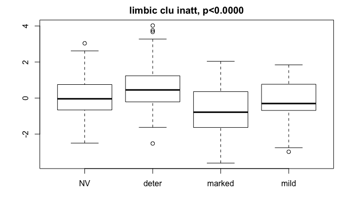

```r
fm = as.formula(mycluster ~ df$OLS_inatt_categ)
fit = aov(lm(fm))
boxplot(fm)
title(sprintf('limbic clu inatt, p<%.4f', summary(fit)[[1]][1, 'Pr(>F)']))
```

Yep, that’s decent enough. Let’s add it to the output.

```r
tmp_df = data.frame(MRN=df$MRN, inatt_limbic=mycluster)
out_df = merge(out_df, tmp_df, all.x=T, all.y=T)
dim(out_df)
```

```
[1] 275   7
```

Let’s try another cluster:

```r
fm = as.formula('inatt_melodic_VAN.x ~ age_at_scan + I(age_at_scan^2) + enormGoodTRs_fmri01 + I(enormGoodTRs_fmri01^2) + Sex...Subjects')
res.lme = lme(fm, random=~1|nuclearFamID.x, data=df, na.action=na.omit, method='ML')
step <- stepAIC(res.lme, direction = "both", trace = F)
print(summary(step))
```

```
Linear mixed-effects model fit by maximum likelihood
 Data: df
       AIC      BIC    logLik
  543.1341 552.9685 -268.5671

Random effects:
 Formula: ~1 | nuclearFamID.x
        (Intercept)  Residual
StdDev:   0.4569392 0.8421855

Fixed effects: inatt_melodic_VAN.x ~ 1
                 Value  Std.Error  DF  t-value p-value
(Intercept) -0.1679151 0.07163064 154 -2.34418  0.0203

Standardized Within-Group Residuals:
        Min          Q1         Med          Q3         Max
-2.13015106 -0.62411753  0.02620724  0.63931792  3.47964383

Number of Observations: 196
Number of Groups: 154
```

```r
mycluster = residuals(step)
summary(aov(lm(mycluster ~ df$OLS_inatt_categ)))
```

```
                    Df Sum Sq Mean Sq F value   Pr(>F)
df$OLS_inatt_categ   3  18.54   6.179   12.97 9.45e-08 ***
Residuals          192  91.47   0.476
---
Signif. codes:  0 ‘***’ 0.001 ‘**’ 0.01 ‘*’ 0.05 ‘.’ 0.1 ‘ ’ 1
```

```r
pairwise.t.test(mycluster, df$OLS_inatt_categ, p.adjust.method='none')
```

```
    Pairwise comparisons using t tests with pooled SD

data:  mycluster and df$OLS_inatt_categ

       NV      deter   marked
deter  0.00088 -       -
marked 0.00013 2.8e-09 -
mild   0.80327 0.00448 0.00411

P value adjustment method: none
```

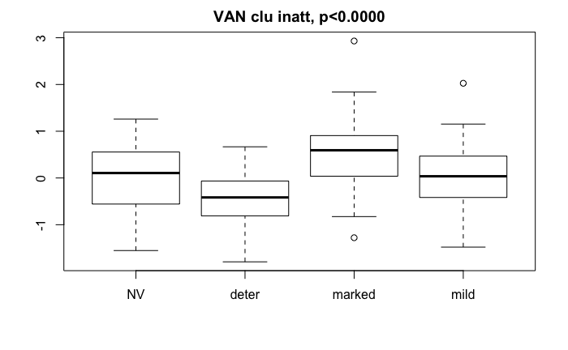

```r
fm = as.formula(mycluster ~ df$OLS_inatt_categ)
fit = aov(lm(fm))
boxplot(fm)
title(sprintf('VAN clu inatt, p<%.4f', summary(fit)[[1]][1, 'Pr(>F)']))
```

Yep, quite good as well. Going in…

```r
tmp_df = data.frame(MRN=df$MRN, inatt_VAN=mycluster)
out_df = merge(out_df, tmp_df, all.x=T, all.y=T)
dim(out_df)
```

```
[1] 275   8
```

And the final rsFMRI cluster:

```r
fm = as.formula('inatt_melodic_DMN.x ~ age_at_scan + I(age_at_scan^2) + enormGoodTRs_fmri01 + I(enormGoodTRs_fmri01^2) + Sex...Subjects')
res.lme = lme(fm, random=~1|nuclearFamID.x, data=df, na.action=na.omit, method='ML')
step <- stepAIC(res.lme, direction = "both", trace = F)
print(summary(step))
```

```
Linear mixed-effects model fit by maximum likelihood
 Data: df
       AIC      BIC    logLik
  650.1937 663.3062 -321.0969

Random effects:
 Formula: ~1 | nuclearFamID.x
         (Intercept) Residual
StdDev: 0.0001713465 1.245218

Fixed effects: inatt_melodic_DMN.x ~ age_at_scan
                 Value Std.Error  DF   t-value p-value
(Intercept)  0.5612723 0.4133144 153  1.357979  0.1765
age_at_scan -0.0602920 0.0404487  41 -1.490579  0.1437
 Correlation:
            (Intr)
age_at_scan -0.976

Standardized Within-Group Residuals:
       Min         Q1        Med         Q3        Max
-3.2977919 -0.6828430 -0.0354131  0.6355995  2.6118111

Number of Observations: 196
Number of Groups: 154
```

```r
mycluster = residuals(step)
summary(aov(lm(mycluster ~ df$OLS_inatt_categ)))
```

```
                    Df Sum Sq Mean Sq F value Pr(>F)
df$OLS_inatt_categ   3  14.03   4.678   3.098  0.028 *
Residuals          192 289.88   1.510
---
Signif. codes:  0 ‘***’ 0.001 ‘**’ 0.01 ‘*’ 0.05 ‘.’ 0.1 ‘ ’ 1
```

```r
pairwise.t.test(mycluster, df$OLS_inatt_categ, p.adjust.method='none')
```

```
    Pairwise comparisons using t tests with pooled SD

data:  mycluster and df$OLS_inatt_categ

       NV     deter  marked
deter  0.4017 -      -
marked 0.0170 0.0054 -
mild   0.2924 0.1110 0.3111

P value adjustment method: none
```

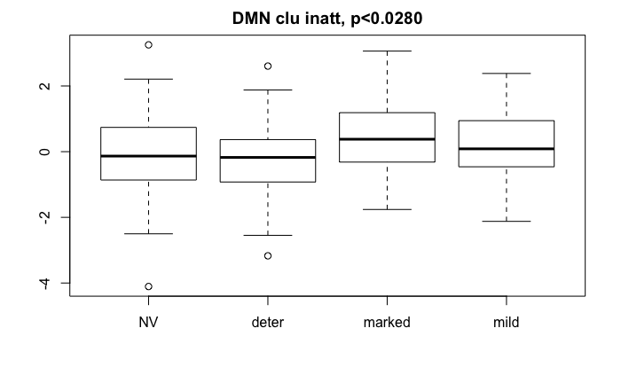

```r
fm = as.formula(mycluster ~ df$OLS_inatt_categ)
fit = aov(lm(fm))
boxplot(fm)
title(sprintf('DMN clu inatt, p<%.4f', summary(fit)[[1]][1, 'Pr(>F)']))
```

Not as good as the other two, but at least it’s the marked improvement group that’s different. Let’s include it too:

```r
tmp_df = data.frame(MRN=df$MRN, inatt_DMN=mycluster)
out_df = merge(out_df, tmp_df, all.x=T, all.y=T)
dim(out_df)
```

```
[1] 275   9
```

```r
write.csv(out_df, file='~/data/baseline_prediction/residualized_combined_OLS_descriptives_02062019.csv',
          row.names=F)
```

OK, let’s try the predictions in Python then.

The goal is to generate different ROC curves to compare the combined model with the individual modality models. We can come back to R to generate logs odds and other descriptives later.